# Visa H-1B in the United States

Probability of an application being denied

Dana Berman

# Exploratory Data Analysis - State Variation

This is an initial analysis performed on a data set obtained on [Kaggle](https://www.kaggle.com/nsharan/h-1b-visa) and containing over 3 million rows. More data can be obtained from the *Office of Foreign Labor Certification* which outputs yearly data sets. See this [link](https://www.dol.gov/agencies/eta/foreign-labor/performance) for more performance indices.

For this section, we load the data set with 4 columns: case status, full time position, worksite and year. The case status is one of

- CERTIFIED-WITHDRAWN
- WITHDRAWN
- CERTIFIED
- DENIED
- REJECTED (only 2 rows)
- INVALIDATED (only 1 row)
- PENDING QUALITY AND COMPLIANCE REVIEW - UNASSIGNED (only 15 rows)
- Not available (nan)

The full time position indicates whether or not a position is full time. The year ranges from 2011 to 2016 and the worksite includes the city and state the job.

Our final goal is to estimate the probability of having an H-1B visa application rejected. In order to demonstrate viability, we show that there is sufficient data to obtain meaningful results. In this notebook, we focus on the relationship between geographic location and ratio of denied applications. In particular, we compute a chi-square statistic to show that the is a clear relationship between work state and the probability of seeing and H-1B application denied.

## Visualization

We plot the ratio of denied to certified applications by state in two different ways. First, as a bar plot and second as choropleth.

### Bar Plot

#### Total

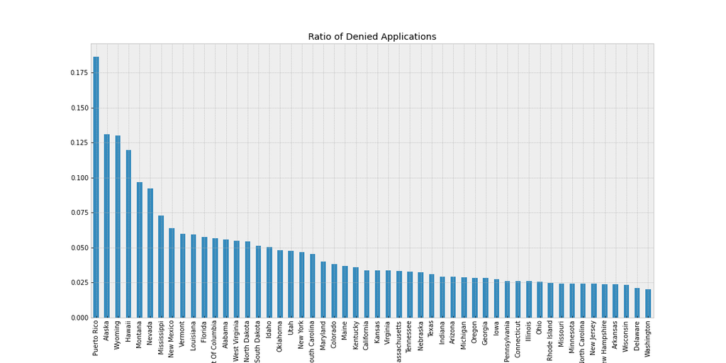

#### 2011

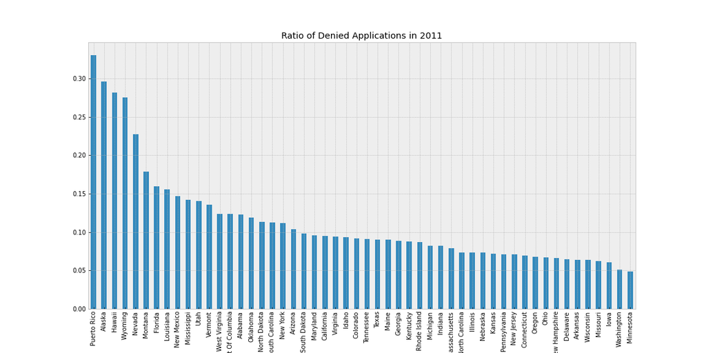

#### 2012

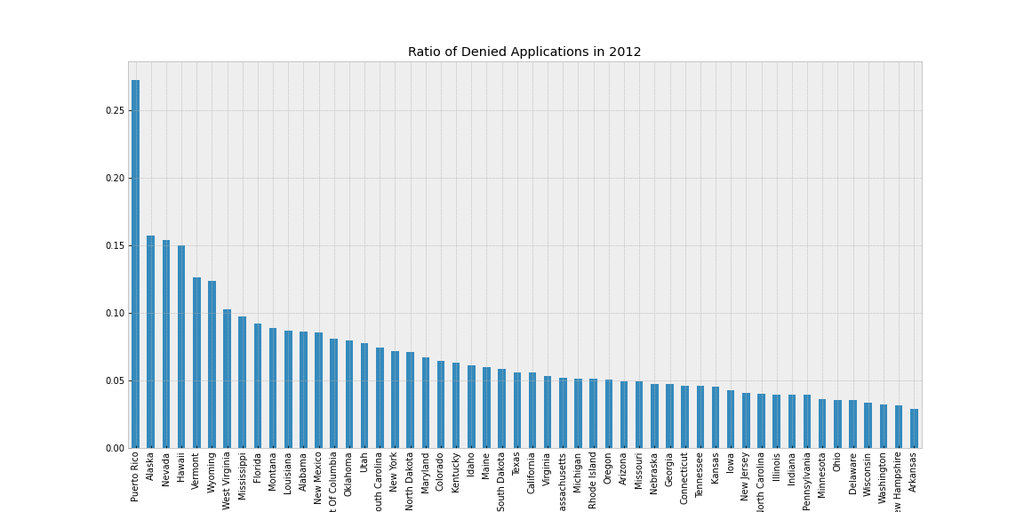

#### 2013

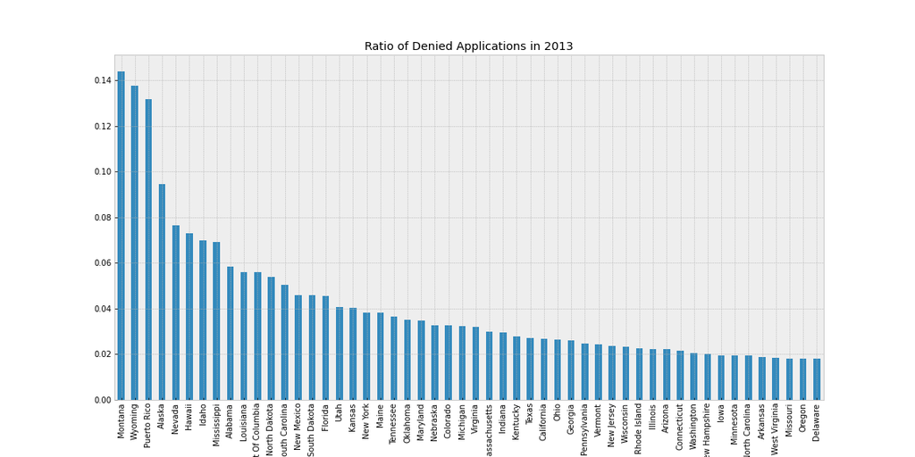

#### 2014

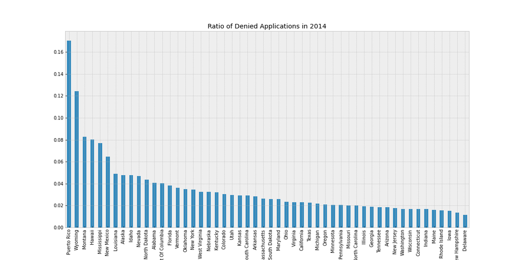

#### 2015

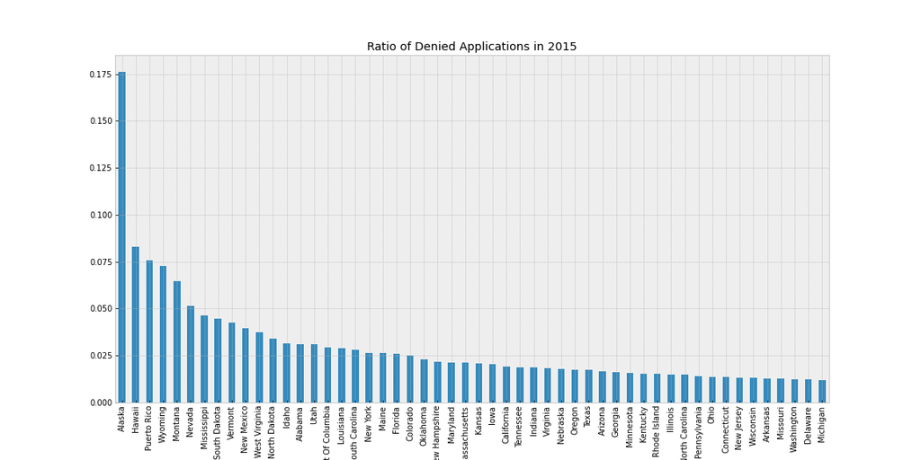

#### 2016

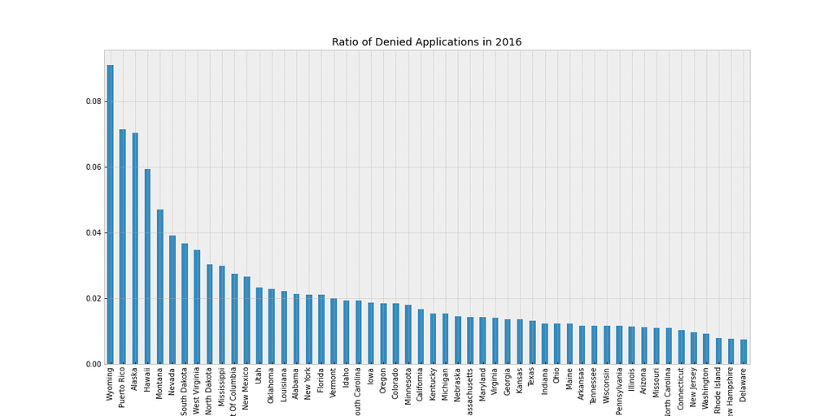

### Map

#### Total

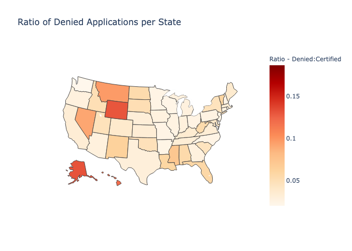

#### 2011

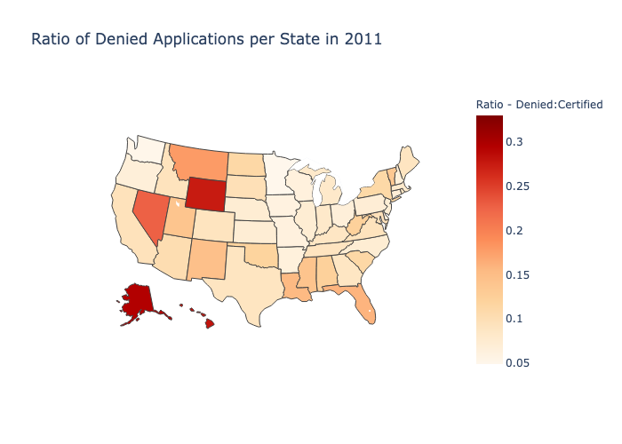

#### 2012

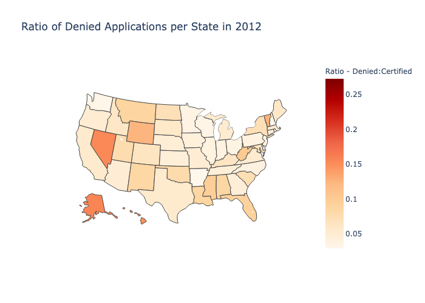

#### 2013

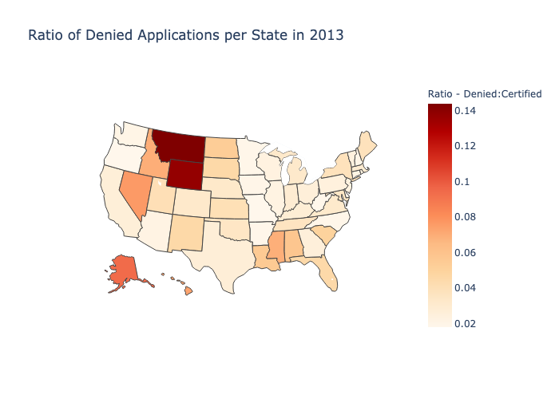

#### 2014

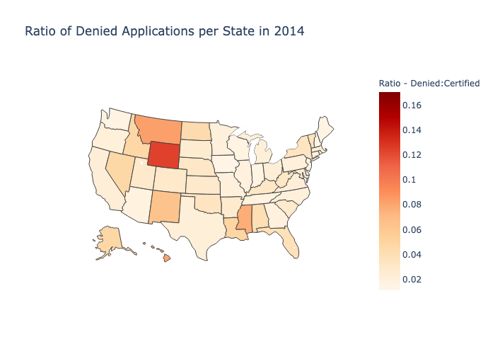

#### 2015

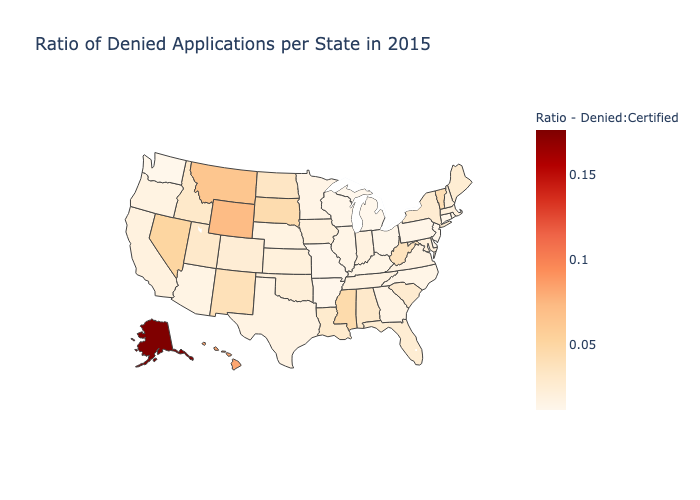

#### 2016

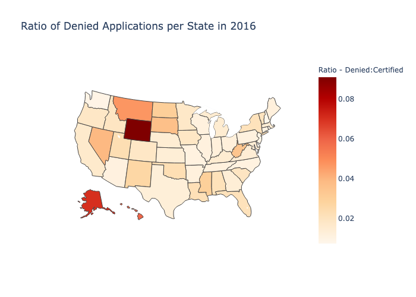

By viewing the maps, we rapidly see that there is a lot of variability from year to year. Further analysis will be necessary to determine whether historical data should be considered when determining the relationship between states and ratio of denied applications.

### Chi-Squared Test

We perform a chi-squared test to see if the number of denied and certified applications is independent of state.

#### Total

The chi square statistic is: 5942.185794207398

This yields a p-value of: 0.0

#### 2011

The chi square statistic is: 901.7005448811624

This yields a p-value of: 5.710971055847382e-156

#### 2012

The chi square statistic is: 1024.7070997666285

This yields a p-value of: 2.5343744842150006e-181

#### 2013

The chi square statistic is: 808.9498666785229

This yields a p-value of: 5.561243575867254e-137

#### 2014

The chi square statistic is: 969.5617905905754

This yields a p-value of: 6.182514042484128e-170

#### 2015

The chi square statistic is: 703.9156179906499

This yields a p-value of: 1.1951374582297314e-115

#### 2016

The chi square statistic is: 688.1314757318049

This yields a p-value of: 1.8379639833896527e-112

#### Conclusion

We see that there is a correlation between location and the ratio of denied:certified applications.

return